# АДМИНИСТРИРОВАНИЕ POSTGRESQL 13. БАЗОВЫЙ КУРС от [PostgresPRO](https://postgrespro.ru/education/courses/DBA1)

**Основные сведения**  
Продолжительность: 3 дня

**Предварительные знания:**  
минимальные представления о базах данных и SQL, знакомство с Unix.

**Какие навыки будут получены:**

- общие сведения об архитектуре PostgreSQL,
- установка, базовая настройка, управление сервером,
- организация данных на логическом и физическом уровнях,
- базовые задачи администрирования,
- управление пользователями и доступом,
- представление о резервном копировании и репликации.
- Руководство слушателя

Перед началом самостоятельного прохождения курса ознакомьтесь с [руководством слушателя](https://postgrespro.ru/education/courses/DBA1). В нем вы найдете инструкцию по настройке рабочего места и указания по выполнению практических заданий.

# 1.Установка и управление сервером

PostgreSQL — программа, которая относится к классу систем управления базами данных. Когда эта программа выполняется, мы называем ее **сервером PostgreSQL** или **экземпляром сервера**.

Данные, которыми управляет PostgreSQL, хранятся в **базах данных**. Один экземпляр PostgreSQL одновременно работает с несколькими базами данных. Этот набор баз данных называется **кластером баз данных**. Подробнее мы будем говорить о базах данных в теме «Организация данных. Базы данных и схемы».

Итак:

- кластер баз данных — это данные в файлах;
- сервер или экземпляр сервера — программа, управляющая кластером баз данных.

# 1.1 Установка из исходных кодов

## Подготовка и установка

### Необходимые пакеты

Установить необходимые для компиляции пакеты:

```
su -

apt update
apt install libreadline-dev tar gzip zlib1g-dev make gcc
```

### Распакова и настройка установки

https://www.postgresql.org/ftp/source/

Скачать архив с исходным кодом и распаковать его:

```
cd /tmp
wget https://ftp.postgresql.org/pub/source/v13.0/postgresql-13.0.tar.gz
tar xzvf postgresql-13.0.tar.gz
ls -ld postgresql-13.0
cd postgresql-13.0
```

Для промышленного использования сервер лучше устанавливать в каталог, доступный на запись только суперпользователю. Кроме того, будем использовать порт 5555 вместо порта 5432 по умолчанию. В команде `configure` можно указать различные параметры конфигурации. Например:

```
make distclean  # очистить результаты предыдущего запуска, если они были
./configure --prefix=/home/user1/pgsql13 --with-pgport=5555
```

### Сборка и установка

Возможные варианты сборки:

1. `make` — сборка только сервера;

```
make
make install
```

```
Для сборки расширений отдельно нужно повторить последние две команды, перейдя в подкаталог `contrib`:
```

```
cd /home/student/postgresql-13.0/contrib
make
make install
```

2. `make world` — сборка сервера, всех расширений и документации (устанавливать расширения дополнительно не нужно).

```
make world
make install-world
```

## Создание кластера

- новый кластер баз данных не может принадлежать суперпользователю ОС; владельцем кластера обычно делают пользователя `postgres`,
- `PGDATA` — удобная переменная для каталога кластера, ее используют некоторые утилиты сервера, когда им нужно узнать расположение кластера (`initdb`, `pg_ctl`),
- файлы конфигурации создаются в каталоге `PGDATA`,
- желательно включить расчет контрольных сумм для страниц с данными.

В процессе инициализации кластера утилита `initdb` создает конфигурационные файлы в этом же каталоге `PGDATA`. Подробнее о файлах конфигурации в одной из следующих тем.

### Включение контрольных сумм

Утилита `initdb` имеет множество ключей, влияющих на ее работу. Один из важных - `-k` или `--data-checksums` - включает подсчет контрольных сумм на страницах данных. Проверка контрольной суммы будет выполняться при обращении к любой странице данных в кластере. Это несколько снижает производительность, но позволяет оперативно обнаружить повреждения в данных.

### Создание каталога для данных

#### Владелец каталога

Для промышленного использования **владельцем каталога** обычно назначают отдельного пользователя ОС. В нашем случае, пусть это будет каталог пользователя `user1` внутри `/home/user1/pgsql13`:

```
su -
chown -R user1 /home
exit

mkdir /home/user1/pgsql13/data
```

#### `PGDATA`

Этот каталог часто называют `PGDATA` по имени переменной окружения, которую удобно использовать при работе с утилитами сервера:

```
export "PGDATA=/home/user1/pgsql13/data/"
```

#### Add to PATH

Все утилиты сервера установлены в подкаталоге `bin/`, который стоит добавить в переменную `PATH`:

```
export "PATH=/home/user1/pgsql13/bin/:$PATH"
```

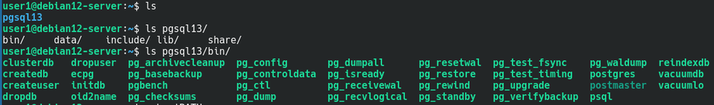

*pgsql13/bin*

### Создание кластера | [`initdb`](https://postgrespro.ru/docs/postgresql/13/app-initdb)

Для инициализации кластера базы данных используется утилита `initdb`:

```
initdb -U postgres -k -D /home/user1/pgsql13/data
```

- `-U` - имя суперпользователя СУБД. Если его не задать, то используется имя пользователя ОС, в нашем случае `user1`. Обычно супер-пользователем является `postgres`, так что зададим это имя явно.
- `-k` - подсчет контрольных суммы страниц, что позволяет своевременно обнаруживать повреждение данных.
- `-D` - каталог для данных, если переменная `PGDATA` не установлена. В нашем случае этот ключ можно было бы не указывать.

If there is an error:

```
initdb: error: invalid locale settings; check LANG and LC_* environment variables
```

then use:

```
initdb -U postgres -k -D /home/user1/pgsql13/data --no-locale --encoding=UTF8
```

or reconfigure locales (choose needed locales):

```
sudo dpkg-reconfigure locales
```

or add line `LC_ALL=<copy_LANG_setting>` to the system file:

```
vi /etc/default/locale
```

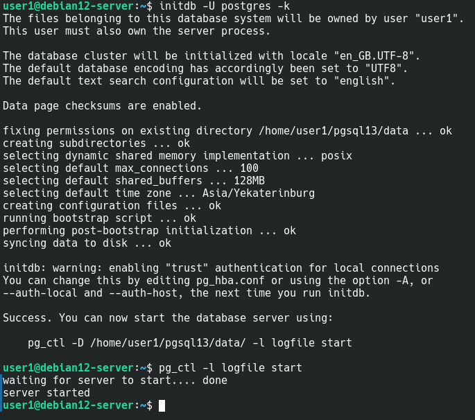

*initdb*

## Управление сервером

- запуск, останов и получение статуса сервера,
- обновление параметров конфигурации,
- переключение на реплику.

### `pg_ctl`

Запускать `pg_ctl` следует от имени владельца кластера баз данных. Более подробная информация об управлении сервером для администраторов баз данных:

- https://postgrespro.ru/docs/postgresql/current/app-pg-ctl
- https://postgrespro.ru/docs/postgresql/current/runtime

### Запуск сервера

- `-l` - файл журнала сообщений сервера.
- `-D` - можно опустить, поскольку задана переменная `PGDATA`.

```
pg_ctl start -l /home/user1/logfile
```

Для проверки работы можно вызвать утилиту `psql`, которая подключится к серверу и вернет текущее время:

```
psql -U postgres [-p 5555] -c 'SELECT now();'
```

```
              now
-------------------------------
 2023-05-28 22:34:49.283736+03
(1 row)
```

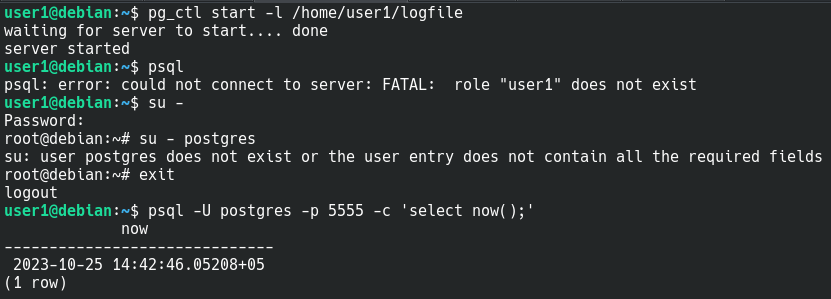

*pg_ctl*

### Останов сервера

```
pg_ctl stop -m fast
```

В ключе `-m` можно указать один из трех режимов останова:

- `fast` — принудительно завершает сеансы и записывает на диск изменения из оперативной памяти;
- `smart` — ожидает завершения всех сеансов и записывает на диск изменения из оперативной памяти;
- `immediate` — принудительно завершает сеансы, при запуске потребуется восстановление.

По умолчанию используется режим `fast`.

```
user1@debian12-server:~$ pg_ctl stop
waiting for server to shut down.... done
server stopped
```

# 1.2 Установка пакета

Предпочтительный способ.

В этом случае получается понятная, поддерживаемаяи легко обновляемая установка. Пакеты существуют для большинства широко распространенных систем. В каждой из них могут быть свои особенности, с которыми стоит ознакомиться перед установкой. В пакетные репозитории некоторых систем уже входит PostgreSQL, но, обычно, не самой последней версии. Актуальная версия может быть взята из репозитория [PostgreSQL Global Development Group (PGDG)](https://www.postgresql.org/download/).

Рассмотрим для Дебиан 12.

## Создание кластера

- инициализация выполняется при установке пакета и создает кластер «main»,
- подсчет контрольных сумм по умолчанию не включен,
- расположение файлов конфигурации и журнала сервера,
- автоматический запуск сервера при старте ОС.

### `pg_createcluster`

Для инициализации кластера в Debian создана обертка `pg_createcluster` над утилитой `initdb`. Справку по использованию `pg_createcluster` можно получить командой:

```
$ man pg_createcluster
```

```bash
man pg_createcluster
```

[output not shown]

[output cut: 220 more lines]

[output not shown]

Утилита `pg_createcluster` автоматически запускается при установке пакета и создает кластер баз данных с именем «`main`». Стоит обратить внимание, что инициализация кластера проходит с *отключенным подсчетом контрольных сумм* в страницах данных.

Исполняемые файлы, файлы конфигурации и журнал сервера размещены в соответствии с правилами, принятыми в Debian. Кроме того, настраивается автоматический запуск и останов сервера PostgreSQL при запуске и останове операционной системы.

### `pg_dropcluster`

Для удаления кластера используется утилита `pg_dropcluster`.

Утилиты `pg_createcluster` и `pg_dropcluster` специфичны для Debian. В других системах нужно явно инициализировать кластерс помощью `initdb` и задействовать подходящие средства операционной системы.

## Установка в Debian

```
su -
apt update
apt install -y postgresql-15
exit
```

Каталог установки PostgreSQL:

```
user1@debian12-server:~$ ls -l /usr/lib/postgresql/15/
```

```
total 8
drwxr-xr-x 2 root root 4096 Oct 25 19:04 bin
drwxr-xr-x 4 root root 4096 Oct 25 19:04 lib
```

Владелец ПО сервера — пользователь `root`.

### `pg_config`

Утилита `pg_config` показывает, с какими параметрами был собран сервер:

```
root@debian12-server: /usr/lib/postgresql/15/bin/pg_config --configure
```

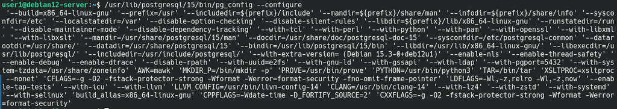

*pg_config*

Кластер баз данных с именем `main` уже инициализирован и находится в каталоге `/var/lib/postgresql/15/main`.

Владельцем каталога является пользователь `postgres`. Вот содержимое каталога:

```
su -
ls -l /var/lib/postgresql/15/main
```

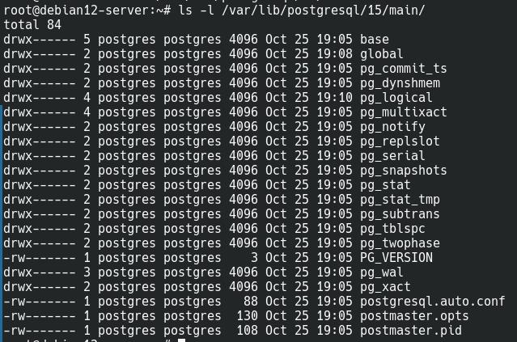

*Cluster `main`*

## `pg_ctlcluster` - Управление сервером

- запуск, останов и получение статуса сервера,
- перечитывание параметров конфигурации,
- переключение на реплику.

В пакетном дистрибутиве для Debian доступ к утилите `pg_ctl` осуществляется не напрямую, а через специальную обертку `pg_ctlcluster`.

В других системах утилита `pg_ctl` может использоваться непосредственно.

```bash
man pg_ctlcluster
```

[output not shown]

[output cut: 62 more lines]

[output not shown]

### Управление сервером в Debian

При установке из пакета в настройки запуска ОС добавляется запуск PostgreSQL. Поэтому после загрузки операционной системы отдельно стартовать PostgreSQL не нужно.

Можно явным образом управлять сервером с помощью следующих команд, которые выдаются либо от имени пользователя ОС postgres, либо через sudo:

| Command | Description |
| --- | --- |
| `pg_ctlcluster 15 main stop` | Остановить сервер |
| `pg_ctlcluster 15 main start` | Запустить сервер |
| `pg_ctlcluster 15 main restart` | Перезапустить |
| `pg_ctlcluster 15 main status` | Получить текущий статус сервера |
| `pg_ctlcluster 15 main reload` | Перечитать файлы конфигурации |

Утилита `pg_ctlcluster` позволяет управлять несколькими серверами разных версий. В качестве параметров утилите передаются:

- `15` — номер версии сервера;
- `main` — название сервера.

```
root@debian12-server: pg_ctlcluster 15 main status
```

```
pg_ctl: server is running (PID: 512)
/usr/lib/postgresql/15/bin/postgres "-D" "/var/lib/postgresql/15/main" "-c" "config_file=/etc/postgresql/15/main/postgresql.conf"
```

Журнал сообщений сервера при пакетной установке находится здесь:

```
ls -l /var/log/postgresql/postgresql-15-main.log
```

Заглянем в конец журнала:

```
tail -f /var/log/postgresql/postgresql-15-main.log
```

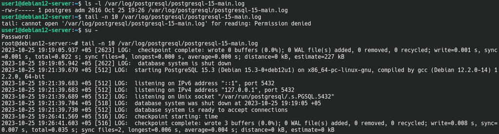

*log*

## Включение расчета контрольных сумм в кластере

1. Остановите сервер.
2. Проверьте, рассчитываются ли контрольные суммыв кластере.
3. Включите расчет контрольных сумм.
4. Запустите сервер.

```
su -
pg_ctlcluster 15 main stop
/usr/lib/postgresql/15/bin/pg_checksums --check -D /var/lib/postgresql/15/main
/usr/lib/postgresql/15/bin/pg_checksums --enable -D /var/lib/postgresql/15/main
pg_ctlcluster 15 main start
```

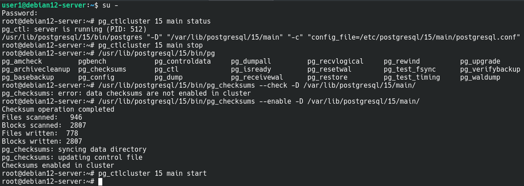

*checksums*

# 2.Использование `psql`

Назначение

- Терминальный клиент для работы с PostgreSQL
- Поставляется вместе с СУБД
- Используется администраторами и разработчиками для интерактивной работы и выполнения скриптов

## Start and Help

| Description | Command |
| --- | --- |
| start db | `psql -h <hostname> -p <port_number> dbname -U uname` |
| new connection in psql | `\c dbname uname hostname port` |
| current connection info | `\conninfo` |
| **Help info** |  |
|  | `psql --help` |
|  | `man psql` |
| psql commands | `\?` |
| psql command-line options | `\? options` |
| psql variables | `\? variables` |
| SQL commands | `\h [sql command]` (`*` for all commands) |
| exit | `q` |

```bash
man psql
```

[output not shown]

[output cut: 2694 more lines]

[output not shown]

## Output configuration

| Description | Command |
| --- | --- |
| align or unalign tuples | `\a` |
| show only tuples without table's head and total rows | `\t [on\\|off]` |
| set table output option | `\pset [NAME [VALUE]]` |
| see table output configuration | `\pset` |
| set fieldseparator | `pset fieldsep '<smth>'` |
| toggle expanded output | `\x [on\\|off\\|auto]` |
| toggle expanded output just for one query | `SELECT * FROM tname WHERE coln='smth' \gx` |

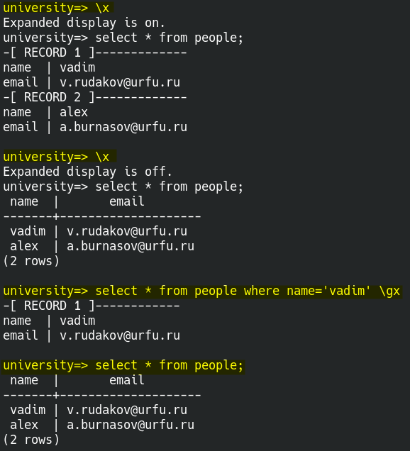

*Expanded output*

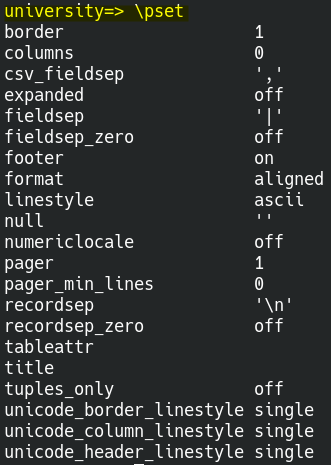

*\pset*

## Interaction with OS

| Description | Command |
| --- | --- |
| bash | `\!` |
| set environment variable | `\setenv TEST Hello` |
| write result into file | `\o test_result` and then `\! cat test_result` |
| return output to the screen | `\o` |

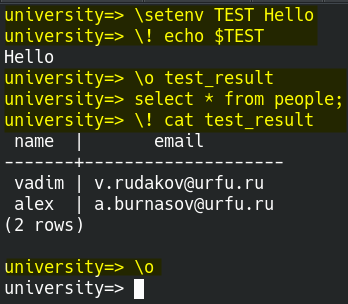

*bash prompt*

## Scripts

```
SELECT format('SELECT COUNT(*) FROM %I;', tablename)
  FROM pg_tables LIMIT 3
  \g (tuples_only=on format=unaligned) test_result

\! cat test_result
```

Let's break it down:

- `format('SELECT COUNT(*) FROM %I;', tablename)` - This uses the format function to generate a string with a placeholder `%I` for the table name. The `%I` placeholder is used for identifiers (like table names), and it handles them in a safe way that helps avoid SQL injection attacks.
- `FROM pg_tables` - This part of the query is fetching the table names from the system catalog `pg_tables`.

The line `\g (tuples_only=on format=unaligned) test_result` is a command used in the PostgreSQL command-line interface psql to execute the previous SQL query and specify the output format.

- `\g` - This command is used in `psql` to send the query to the server for execution. It indicates that the previous SQL command should be executed.
- `(tuples_only=on format=unaligned)` - These are options provided to the `\g` command. They specify the format of the output from the executed SQL query.
  - `tuples_only=on` specifies that only the query result should be displayed without any additional information or column headers.
  - `format=unaligned` specifies that the output should not be aligned in tabular format.
- `test_result` - This is where to save the output of the query. The output of the SQL query will be directed into a file named `test_result`.

So, when this line is executed in the `psql` command-line interface after running a SQL query, it will execute the query, format the output according to the specified options, and save the result into the `test_result` file.

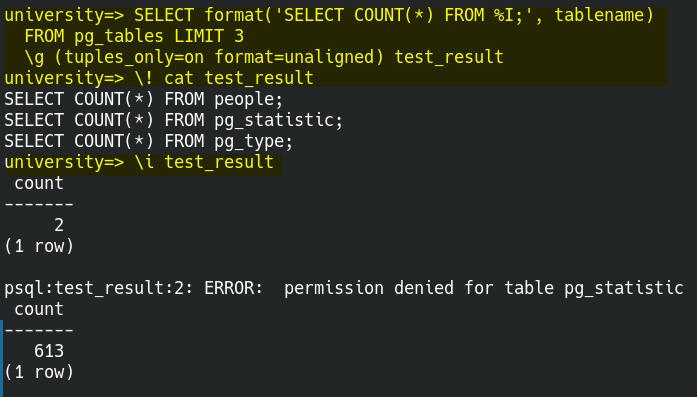

*scripts*

Также вывод запроса можно отправить команде ОС, если указать `\g | cmd`.

Способы выполнить скрипт:

1. `\i[nteractive]`

```
\i test_result
```

2. `psql < test_result`
3. `psql -f test_result`

Также можно сразу запустить команды без записи в файл:

```
SELECT format('SELECT COUNT(*) FROM %I;', tablename)
  FROM pg_tables LIMIT 3
  \gexec
```

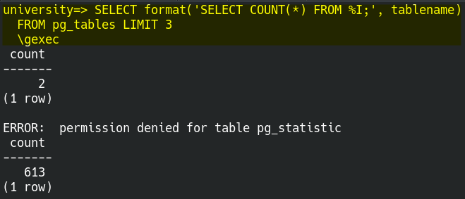

*\gexec*